# Describe Health and Sleep Quality Data

## Sleep Health and Lifestyle Analysis

#### Project Instructions

There are four sections of this project that you will need to complete. Below you will find directions to assist with each portion of this project.

#### Question-set-1 [Data Description]

As you inspect the health and sleep quality dataset, notice there are examples of all the data types you are now familiar with.

On this slide, provide an example of each of the following:

```
1a - ____________ is an example of a continuous variable in the dataset.
1b - ____________ is an example of an integer variable in the dataset.
1c - ____________ is an example of an ordinal categorical variable in the dataset.
1d - ____________ is an example of a nominal categorical variable in the dataset.
```

Notice there are often multiple columns that could fit the category above.

#### Question-set-2 [Typical Amount (Minutes) of Physical Activity]

```
2a - On this slide, provide the mean, median, and mode number of minutes of physical activity in the dataset.
2b - Standout suggestion: What do the relationships between these values suggest about the skewness of the distribution associated with physical activity?
```

#### Question-set-3 [Analysis of Daily Steps Taken]

```
3a - On this slide, provide the standard deviation, maximum, minimum, and range associated with the number of steps taken.
3b - Standout suggestion: Provide any other measures of spread you think might be helpful to understand the dataset.
```

#### Question-set-4 [Distribution of Heart Rates]

```
4a - On this slide, include a plot (graph) of the distribution of heart rates. What is the shape of the distribution? Are there any outliers?
```

#### Dataset Overview

The Sleep Health and Lifestyle Dataset comprises a wide range of variables related to sleep and daily habits. It includes details such as gender, age, occupation, sleep duration, quality of sleep, physical activity level, stress levels, BMI category, blood pressure, heart rate, daily steps, and the presence or absence of sleep disorders.

#### Dataset Columns:

Person ID: An identifier for each individual.

Gender: The gender of the person (Male/Female).

Age: The age of the person in years.

Occupation: The occupation or profession of the person.

Sleep Duration (hours): The number of hours the person sleeps per day.

Quality of Sleep (scale: 1-10): A subjective rating of the quality of sleep, ranging from 1 to 10.

Physical Activity Level (minutes/day): The number of minutes the person engages in physical activity daily.

Stress Level (scale: 1-10): A subjective rating of the stress level experienced by the person, ranging from 1 to 10.

BMI Category: The BMI category of the person (e.g., Underweight, Normal, Overweight).

Blood Pressure (systolic/diastolic): The blood pressure measurement of the person, indicated as systolic pressure over diastolic pressure.

Heart Rate (bpm): The resting heart rate of the person in beats per minute.

Daily Steps: The number of steps the person takes per day.

Sleep Disorder: The presence or absence of a sleep disorder in the person (None, Insomnia, Sleep Apnea).

#### Details about Sleep Disorder Column:

None: The individual does not exhibit any specific sleep disorder. Insomnia: The individual experiences difficulty falling asleep or staying asleep, leading to inadequate or poor-quality sleep. Sleep Apnea: The individual suffers from pauses in breathing during sleep, resulting in disrupted sleep patterns and potential health risks.

```python
#### Load the data

import importlib
import utility as utl
importlib . reload( utl )

import numpy as np
import pandas as pd

import matplotlib.pyplot as plt
%matplotlib inline

lifestyle_df = pd.read_csv('sleep_health_and_lifestyle_dataset-sleep_health_and_lifestyle_dataset.csv')
print("Shape of lifestyle_df ---> ", lifestyle_df.shape)
```

```
Shape of lifestyle_df --->  (374, 13)
```

```python
print("Display few lifestyle data... ")
lifestyle_df.head(3)
```

```
Display few lifestyle data...
```

|  | Person ID | Gender | Age | Occupation | Sleep Duration | Quality of Sleep | Physical Activity Level | Stress Level | BMI Category | Blood Pressure | Heart Rate | Daily Steps | Sleep Disorder |
| --- | --- | --- | --- | --- | --- | --- | --- | --- | --- | --- | --- | --- | --- |
| 0 | 1 | Male | 27 | Software Engineer | 6.1 | 6 | 42 | 6 | Overweight | 126/83 | 77 | 4200 | NaN |
| 1 | 2 | Male | 28 | Doctor | 6.2 | 6 | 60 | 8 | Normal | 125/80 | 75 | 10000 | NaN |
| 2 | 3 | Male | 28 | Doctor | 6.2 | 6 | 60 | 8 | Normal | 125/80 | 75 | 10000 | NaN |

## 1 - Data Description

#### Check few basic information - list of columns, basic dataset information and statistics

```python
#### Print all columns for clarity
columns = lifestyle_df.columns
for i, column in enumerate(columns):
    print(i, " --- ", column)
```

```
0  ---  Person ID
1  ---  Gender
2  ---  Age
3  ---  Occupation
4  ---  Sleep Duration
5  ---  Quality of Sleep
6  ---  Physical Activity Level
7  ---  Stress Level
8  ---  BMI Category
9  ---  Blood Pressure
10  ---  Heart Rate
11  ---  Daily Steps
12  ---  Sleep Disorder
```

```python
#### Retrieve the table information
lifestyle_df.info()
```

```
<class 'pandas.core.frame.DataFrame'>
RangeIndex: 374 entries, 0 to 373
Data columns (total 13 columns):
 #   Column                   Non-Null Count  Dtype
---  ------                   --------------  -----
 0   Person ID                374 non-null    int64
 1   Gender                   374 non-null    object
 2   Age                      374 non-null    int64
 3   Occupation               374 non-null    object
 4   Sleep Duration           374 non-null    float64
 5   Quality of Sleep         374 non-null    int64
 6   Physical Activity Level  374 non-null    int64
 7   Stress Level             374 non-null    int64
 8   BMI Category             374 non-null    object
 9   Blood Pressure           374 non-null    object
 10  Heart Rate               374 non-null    int64
 11  Daily Steps              374 non-null    int64
 12  Sleep Disorder           155 non-null    object
dtypes: float64(1), int64(7), object(5)
memory usage: 38.1+ KB
```

```python
#### Fetch the basic statistics
lifestyle_df.describe()
```

|  | Person ID | Age | Sleep Duration | Quality of Sleep | Physical Activity Level | Stress Level | Heart Rate | Daily Steps |
| --- | --- | --- | --- | --- | --- | --- | --- | --- |
| count | 374.000000 | 374.000000 | 374.000000 | 374.000000 | 374.000000 | 374.000000 | 374.000000 | 374.000000 |
| mean | 187.500000 | 42.184492 | 7.132086 | 7.312834 | 59.171123 | 5.385027 | 70.165775 | 6816.844920 |
| std | 108.108742 | 8.673133 | 0.795657 | 1.196956 | 20.830804 | 1.774526 | 4.135676 | 1617.915679 |
| min | 1.000000 | 27.000000 | 5.800000 | 4.000000 | 30.000000 | 3.000000 | 65.000000 | 3000.000000 |
| 25% | 94.250000 | 35.250000 | 6.400000 | 6.000000 | 45.000000 | 4.000000 | 68.000000 | 5600.000000 |
| 50% | 187.500000 | 43.000000 | 7.200000 | 7.000000 | 60.000000 | 5.000000 | 70.000000 | 7000.000000 |
| 75% | 280.750000 | 50.000000 | 7.800000 | 8.000000 | 75.000000 | 7.000000 | 72.000000 | 8000.000000 |
| max | 374.000000 | 59.000000 | 8.500000 | 9.000000 | 90.000000 | 8.000000 | 86.000000 | 10000.000000 |

#### Answer-set-1 [Data Description]

```
- Sleep Duration is an example of a continuous variable because it can take fractional numerical values and is measured on a continuous scale.
- Daily Steps is an example of an integer variable because it represents count-based whole-number observations.
- Quality of Sleep is an example of an ordinal categorical variable because the categories have a meaningful order from lower to higher quality.
- Gender is an example of a nominal categorical variable because the categories do not have any natural ranking or order.
```

## 2 - Physical Activity Level (minutes/day)

#### Basic statistics of 'Physical Activity Level'

```python
lifestyle_df['Physical Activity Level'].describe()
```

```
count    374.000000
mean      59.171123
std       20.830804
min       30.000000
25%       45.000000
50%       60.000000
75%       75.000000
max       90.000000
Name: Physical Activity Level, dtype: float64
```

```python
mean_pa = lifestyle_df['Physical Activity Level'].mean()
median_pa = lifestyle_df['Physical Activity Level'].median()
mode_pa = lifestyle_df['Physical Activity Level'].mode()[0]

print('Mean of Physical Activity Level = ', mean_pa)
print('Median of Physical Activity Level = ', median_pa)
print('Mode of Physical Activity Level = ', mode_pa)
```

```
Mean of Physical Activity Level =  59.17112299465241
Median of Physical Activity Level =  60.0
Mode of Physical Activity Level =  60
```

#### Answer-set-2 [Typical Amount (Minutes) of Physical Activity]

```
2a - On this slide, provide the mean, median, and mode number of minutes of physical activity in the dataset.
   - Mean = 59.17112299465241
   - Median = 60.0
   - Mode = 60.0
2b - Standout suggestion: What do the relationships between these values suggest about the skewness of the distribution associated with physical activity?
   - The mean is slightly lower than, but very close to, the median, suggesting a mildly left-skewed distribution.
```

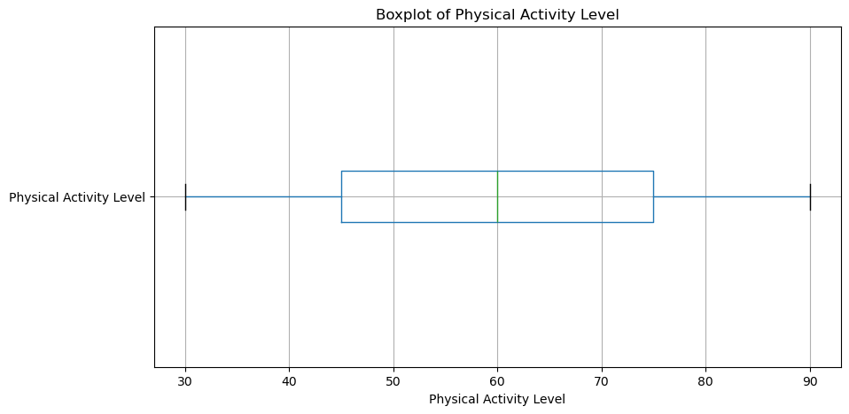

```python
fig, ax = plt.subplots(figsize=(10, 5))

lifestyle_df.boxplot(column='Physical Activity Level', vert=False, ax=ax)
utl.x_y_t(ax, 'Physical Activity Level', '',
          'Boxplot of Physical Activity Level')

plt.show()
```

#### Note: The boxplot suggests that the distribution of physical activity levels is relatively symmetric with moderate spread and no extreme outliers.

## 3 - Analysis of Daily Steps Taken

#### Basic statistics of 'Daily Steps'

```python
lifestyle_df['Daily Steps'].describe()
```

```
count      374.000000
mean      6816.844920
std       1617.915679
min       3000.000000
25%       5600.000000
50%       7000.000000
75%       8000.000000
max      10000.000000
Name: Daily Steps, dtype: float64
```

```python
daily_steps = lifestyle_df['Daily Steps']

std_val = daily_steps.std()
max_val = daily_steps.max()
min_val = daily_steps.min()
range_val = max_val - min_val

print('Standard Deviation = ', std_val)
print('Maximum = ', max_val)
print('Minumum = ', min_val)
print('Range = ', range_val)
```

```
Standard Deviation =  1617.915679133637
Maximum =  10000
Minumum =  3000
Range =  7000
```

```
3a - On this slide, provide the standard deviation, maximum, minimum, and range associated with the number of steps taken.
   - Standard Deviation = 1617.915679133637
   - Maximum = 10000
   - Minumum = 3000
   - Range = 7000
   - The large range and standard deviation indicate substantial variability in the number of daily steps among participants.
3b - We can use IQR and the boxplot.
```

```python
q1 = lifestyle_df['Daily Steps'].quantile(0.25)
q3 = lifestyle_df['Daily Steps'].quantile(0.75)
iqr = q3 - q1

print("Q1:", q1)
print("Q3:", q3)
print("IQR:", iqr)
```

```
Q1: 5600.0
Q3: 8000.0
IQR: 2400.0
```

#### Note: The interquartile range (IQR) measures the spread of the middle 50% of the data and is less affected by outliers than the overall range.

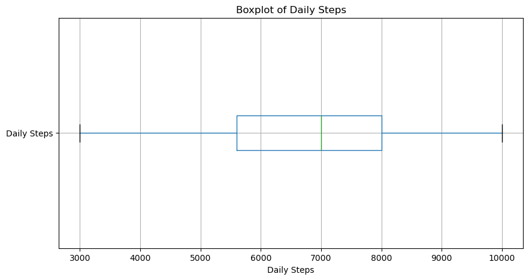

```python
fig, ax = plt.subplots(figsize=(10,5))

lifestyle_df.boxplot(column='Daily Steps', vert=False, ax=ax)
utl.x_y_t(ax, 'Daily Steps', '', 'Boxplot of Daily Steps')

plt.show()
```

#### Note: In addition to the standard deviation and range, the interquartile range (IQR) was calculated to better understand the spread of the middle 50% of the data. The IQR is less sensitive to extreme values and provides a robust measure of variability.

## 4 - Distribution of Heart Rates

#### Basic statistics of 'Heart Rates'

```python
lifestyle_df['Heart Rate'].describe()
```

```
count    374.000000
mean      70.165775
std        4.135676
min       65.000000
25%       68.000000
50%       70.000000
75%       72.000000
max       86.000000
Name: Heart Rate, dtype: float64
```

```python
heart_rate = lifestyle_df['Heart Rate']

print("Mean:", heart_rate.mean())
print("Median:", heart_rate.median())
print("Skew:", heart_rate.skew())
```

```
Mean: 70.16577540106952
Median: 70.0
Skew: 1.2248235470533522
```

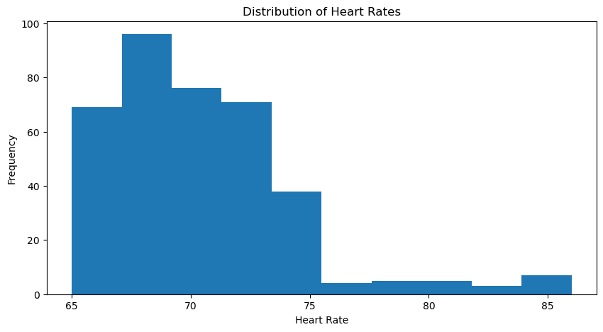

```python
fig, ax = plt.subplots(figsize=(10,5))

lifestyle_df['Heart Rate'].plot(kind='hist', bins=10, ax=ax)
utl.x_y_t(ax,
          'Heart Rate',
          'Frequency',
          'Distribution of Heart Rates')

plt.show()
```

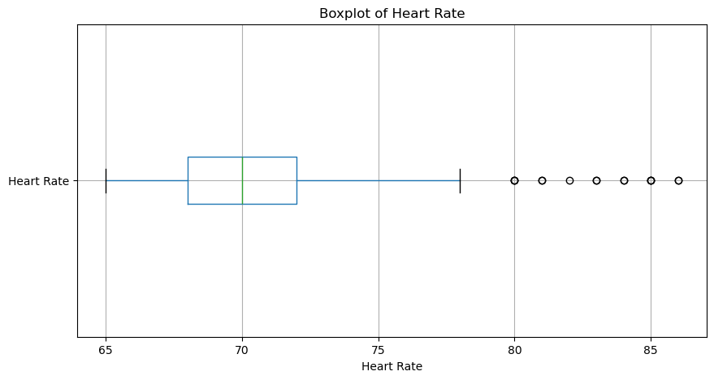

```python
fig, ax = plt.subplots(figsize=(10,5))

lifestyle_df.boxplot(column='Heart Rate', vert=False, ax=ax)
utl.x_y_t(ax,
          'Heart Rate',
          '',
          'Boxplot of Heart Rate')

plt.show()
```

#### Answer-set-4 [Distribution of Heart Rates]

[output not shown]

#### Conclusion

[output not shown]

Overall, the project demonstrates how descriptive statistics and visualization techniques can be used to better understand patterns and distributions within health and lifestyle data.